# Report

## Data loading

Firstly, we load the data.

```r
sale <- read.csv("summer-products-with-rating-and-performance_2020-08.csv")
```

## Data cleaning

We eliminate the column don’t have valuable information.

```r
drop <- c('title','title_orig','currency_buyer','merchant_id','product_id', 'theme', 'crawl_month','merchant_name','merchant_info_subtitle','merchant_title','urgency_text','shipping_option_name','sale$merchant_profile_picture', 'sale$product_url', 'sale$product_picture')
sale <-  sale[,!(names(sale) %in% drop)]
```

We replace the empty value in merchant_profile_picture, product_url, product_picture with 0, non-empty value with 1

```r
sale$merchant_profile_picture <- ifelse(sale$merchant_profile_picture == "", 0,1)
sale$product_url <- ifelse(sale$product_url == "", 0,1)
sale$product_picture <- ifelse(sale$product_picture == "", 0,1)
```

We replace empty value with 0

```r
sale$rating_five_count[is.na(sale$rating_five_count)] <- 0
sale$rating_four_count[is.na(sale$rating_four_count)] <- 0
sale$rating_three_count[is.na(sale$rating_three_count)] <- 0
sale$rating_two_count[is.na(sale$rating_two_count)] <- 0
sale$rating_one_count[is.na(sale$rating_one_count)] <- 0
sale$has_urgency_banner[is.na(sale$has_urgency_banner)] <- 0
```

## Exploratory analysis

1/ Country  
We look at the country column.

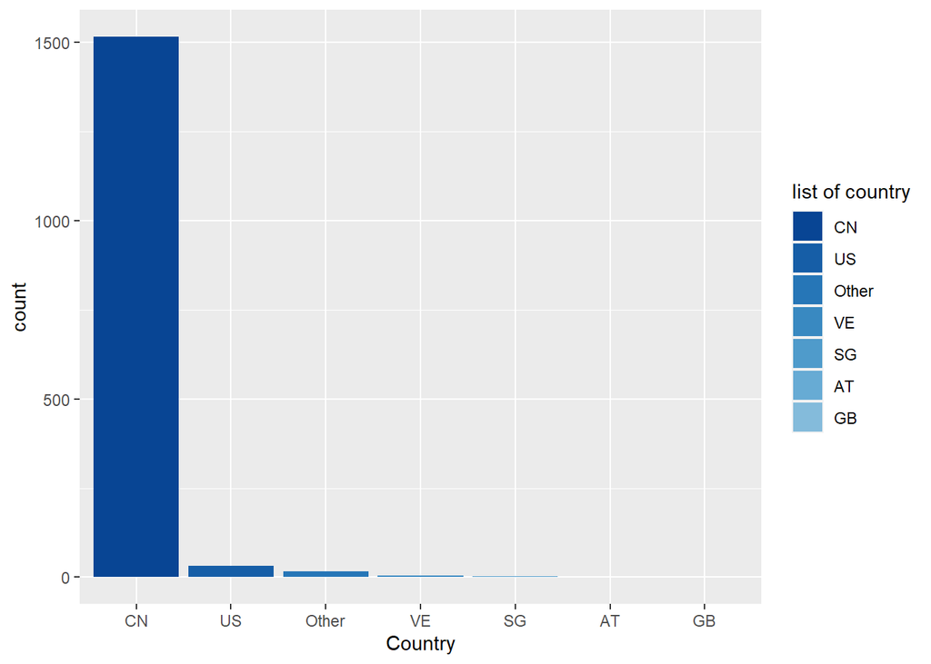

```r
nb.cols <- 13
a <- levels(fct_infreq(sale$origin_country))
mycolors <- colorRampPalette(brewer.pal(8, "Blues"))(nb.cols)
g <- ggplot(data = sale) + geom_bar(aes(x=fct_infreq(origin_country), fill = fct_infreq(origin_country)),stat="count") + xlab('Country')
g <- g + scale_fill_manual(values = rev(mycolors)) + labs(fill = "list of country")
g
```

United State an China have the largest proportion so we convert others countries to “other”

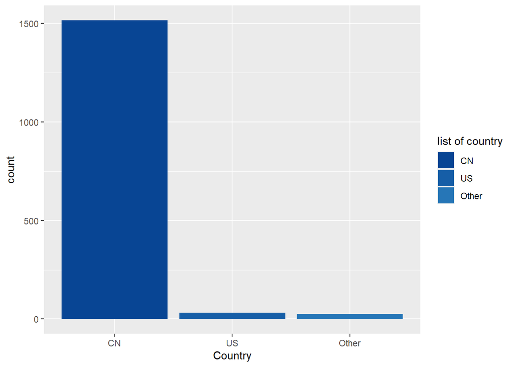

```r
nb.cols <- 13
index <- sale$origin_country %in% c('VE', 'SG', 'AT', 'GB')
sale$origin_country[index] <- "Other"
mycolors <- colorRampPalette(brewer.pal(8, "Blues"))(nb.cols)
g <- ggplot(data = sale) + geom_bar(aes(x=fct_infreq(origin_country), fill = fct_infreq(origin_country)),stat="count") + xlab('Country')
g <- g + scale_fill_manual(values = rev(mycolors)) + labs(fill = "list of country")
g
```

2/ Size  
We can see clearly that there are too many sizes so we transform to 4 catagories “S”, “M”, “L”, “XL”.

```r
sale$product_variation_size_id <- as.character(sale$product_variation_size_id)
index <- sale$product_variation_size_id %in% c('33', '34', '2XL', '32/L','35','36','EU 35','EU39(US8)','L.','Round','Size-L','Size-L','SizeL')
sale$product_variation_size_id[index] <- "L"

index <- sale$product_variation_size_id %in% c('1m by 3m', '20pcs', '20PCS-10PAIRS', '25','25-S','26(Waist 72cm 28inch)','29','3 layered anklet','30 cm','B','Base Coat','daughter 24M','first  generation','H01','M.','One Size','Pack of 1','US 6.5 (EU 37)','US5.5-EU35','White','Women Size 36','Women Size 37','Size M')
sale$product_variation_size_id[index] <- "M"

index <- sale$product_variation_size_id %in% c('10pcs', '1pc', '2', '2pcs','4','4-5 Years','5','5PAIRS','AU plug Low quality','Baby Float Boat','Base & Top & Matte Top Coat','choose a size','Floating Chair for Kid','pants-S','s','S (waist58-62cm)','S Diameter 30cm','S Pink','S(bust 88cm)','S(Pink & Black)','S.','S..','S/M(child)','Size--S','Size-S','Size-S','Size-XS','Size XXS','SIZE XXS','Size/S','Suit-S','US-S','XS','XS.','XXS','XXXS','1','1 pc.','10 ml','17','Size-XXS','SIZE-XXS','Size -XXS','size S','Size S','Size S.','SIZE XS','','SIZE S','')
sale$product_variation_size_id[index] <- "S"

index <- sale$product_variation_size_id == ""
sale$product_variation_size_id[index] <- "S"

index <- sale$product_variation_size_id == "SIZE S"
sale$product_variation_size_id[index] <- "S"

index <- sale$product_variation_size_id %in% c('100 cm', '100 x 100cm(39.3 x 39.3inch)', '100pcs', '04-3XL','1 PC - XL','2XL','3XL','40 cm','4XL','5XL','60','6XL','80 X 200 CM','SIZE-4XL','Size-5XL','SIZE-4XL','Size-5XL','Size4XL','X   L','XXL','XXXL','XXXXL','XXXXXL')
sale$product_variation_size_id[index] <- "XL"
```

Plot

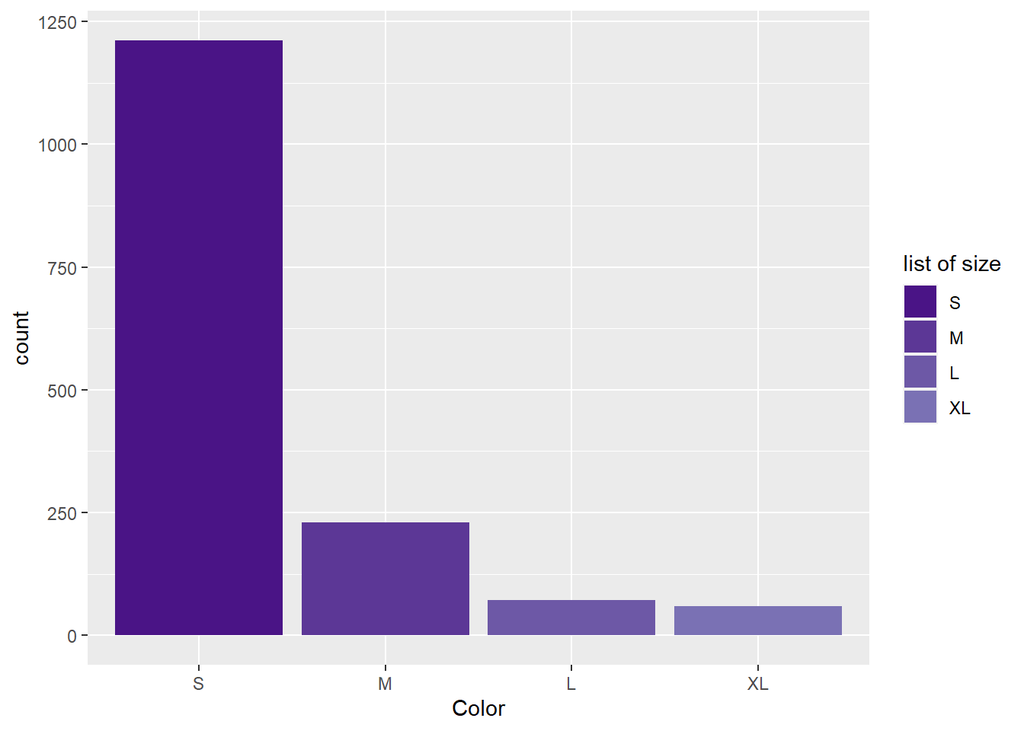

```r
nb.cols <- 13
mycolors <- colorRampPalette(brewer.pal(8, "Purples"))(nb.cols)
g <- ggplot(data = sale) + geom_bar(aes(x=fct_infreq(product_variation_size_id), fill = fct_infreq(product_variation_size_id)),stat="count") + xlab('Color')
g <- g + scale_fill_manual(values = rev(mycolors)) + labs(fill = "list of size")
g
```

3/ Color

We transform colors to some standard values

```r
sale$product_color <- as.character(sale$product_color)

index <- sale$product_color == ''
sale$product_color[index] <- "other"

index <- sale$product_color %in% c("applegreen",'apricot','army','army green','Army green','armygreen','camel','camel','camouflage','claret','darkgreen','floral','fluorescentgreen','ivory','jasper','light green','lightgreen','mintgreen')
sale$product_color[index] <- "green"

index <- sale$product_color %in% c('beige','brown & yellow','burgundy','coffee','khaki','lightkhaki')
sale$product_color[index] <- "brown"

index <- sale$product_color %in% c('Black','black & blue','black & green','black & stripe','black & white','black & yellow','blackwhite','coolblack','offblack')
sale$product_color[index] <- "black"

index <- sale$product_color %in% c('Blue','blue & pink','coralred','darkblue','denimblue','lakeblue','lightblue','navy','navy blue','navyblue','navyblue & white','prussianblue','skyblue')
sale$product_color[index] <- "blue"

index <- sale$product_color %in% c('dustypink','lightpink','Pink','pink & black','pink & blue','pink & blue','pink & grey','pink & white')
sale$product_color[index] <- "pink"

index <- sale$product_color %in% c('gold','leopard','leopardprint','lightyellow','rosegold')
sale$product_color[index] <- "yellow"
index <- sale$product_color %in% c('gray & white','greysnakeskinprint','lightgray','lightgrey')
sale$product_color[index] <- "gray"

index <- sale$product_color %in% c('lightpurple','violet')
sale$product_color[index] <- "purple"

index <- sale$product_color %in% c('lightred','RED','red & blue','rose','Rose red','rosered','watermelonred','wine','wine red','winered','winered & yellow')
sale$product_color[index] <- "red"

index <- sale$product_color %in% c('multicolor','nude','rainbow','silver','star','tan')
sale$product_color[index] <- "other"

index <- sale$product_color %in% c('offwhite','White','white & black','white & green','white & red','whitefloral','whitestripe')
sale$product_color[index] <- "white"

index <- sale$product_color %in% c('orange-red','orange & camouflage')
sale$product_color[index] <- "orange"
```

Plot

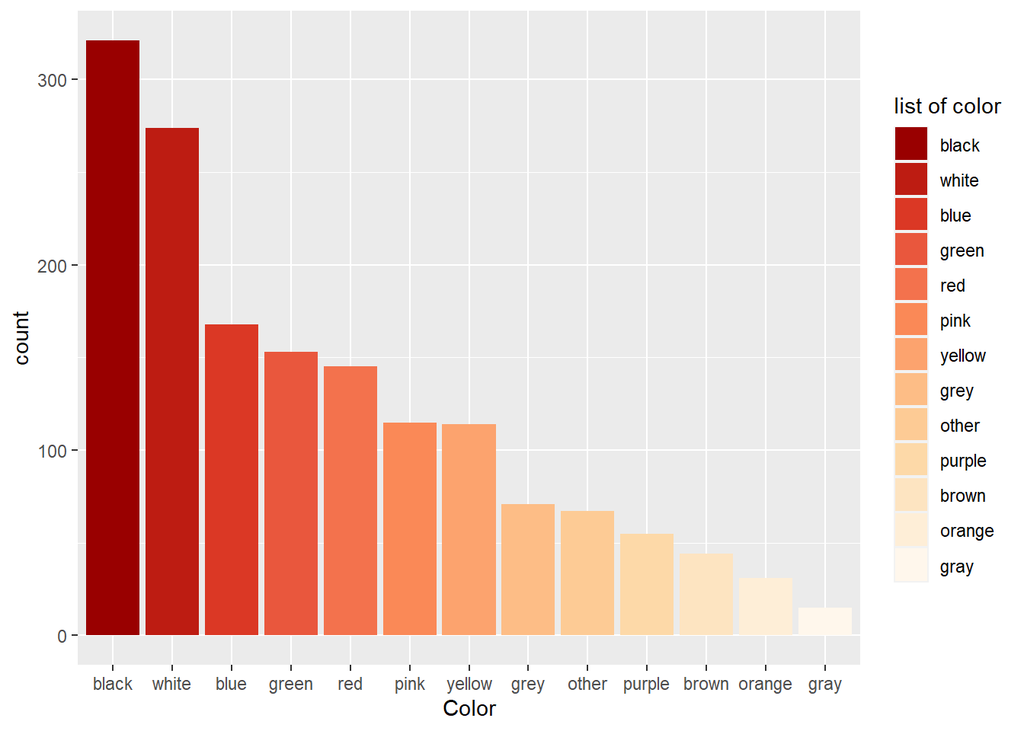

```r
nb.cols <- 13
mycolors <- colorRampPalette(brewer.pal(8, "OrRd"))(nb.cols)
g <- ggplot(data = sale) + geom_bar(aes(x=fct_infreq(product_color), fill = fct_infreq(product_color)),stat="count") + xlab('Color')
g <- g + scale_fill_manual(values = rev(mycolors)) + labs(fill = "list of color")
g
```

4/ Unit sold

We transform rows which has the unit sold less than 10 to 10.

```r
index <- sale$units_sold < 10
sale$units_sold[index] <- 10
```

Plot

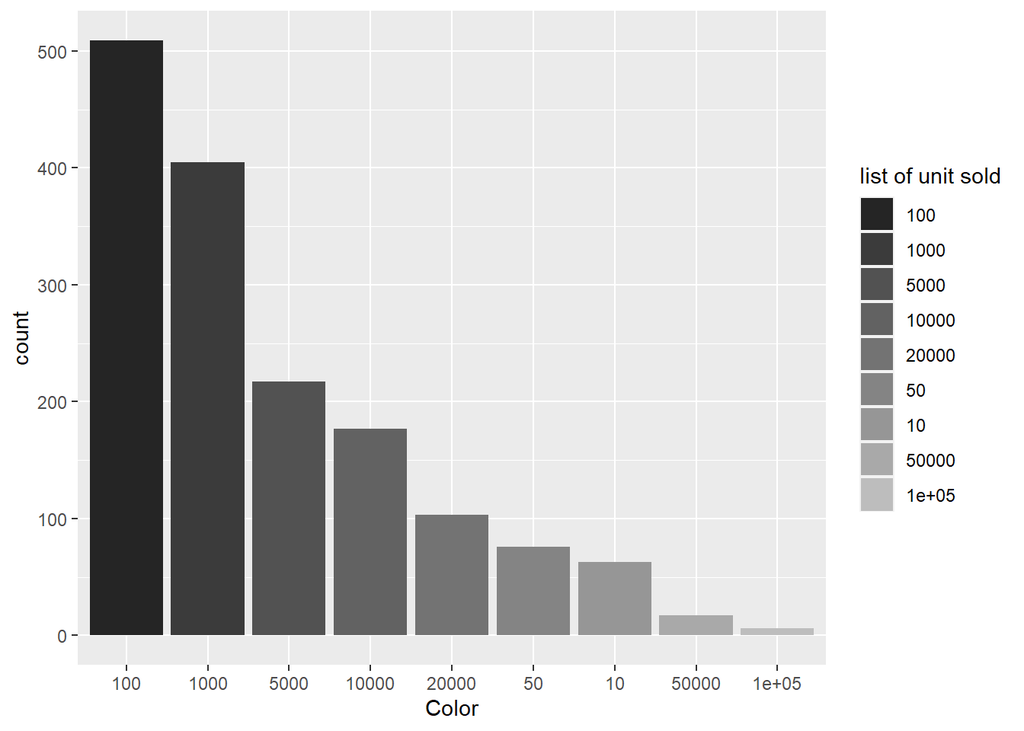

```r
sale$units_sold <- as.factor(sale$units_sold)
nb.cols <- 15
mycolors <- colorRampPalette(brewer.pal(8, "Greys"))(nb.cols)
g <- ggplot(data = sale) + geom_bar(aes(x=fct_infreq(units_sold), fill = fct_infreq(units_sold)),stat="count") + xlab('Color') + labs(fill='Count')
g <- g + scale_fill_manual(values = rev(mycolors)) + labs(fill = "list of unit sold")
g
```

5/ Tags

Plot top popular tags

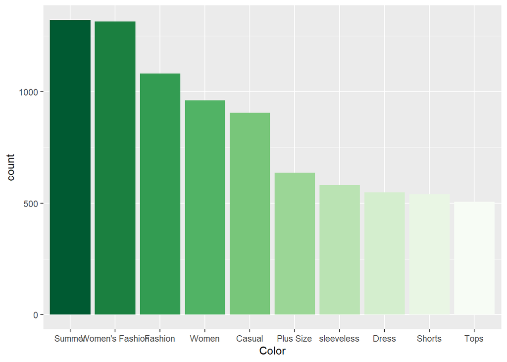

```r
popular_tag <- read.csv('unique-categories.sorted-by-count.csv')
top50 <- as.character(head(popular_tag$keyword, 50))
top50 <- tolower(top50)
top50 <- as.list(top50)
nb.cols <- 10
mycolors <- colorRampPalette(brewer.pal(8, "Greens"))(nb.cols)
g <- ggplot(data = head(popular_tag, 10)) + geom_bar(aes(x=reorder(keyword, -count),y = count, fill = as.factor(count)),stat="identity",show.legend = FALSE) + xlab('Color') + labs(fill='Count')
g <- g + scale_fill_manual(values = mycolors) + labs(fill = "list of tag")
g
```

Because tags column contains many noise so we eliminate it. We add a column with information about the number of popular tag.

```r
replacetag <- function(tag, top50)
{
  tag <- as.character(tag)
  temp <- strsplit(tolower(tag), ",")
  inter <- intersect(temp[[1]], top50)
  return (length(inter) / length(top50))
}
sale$tag_count <- sapply(sale$tags, FUN = replacetag, top50)
drop <- 'tags'
sale <-  sale[,!(names(sale) %in% drop)]
```

```r
drop <- c('rating_count')
sale <-  sale[,!(names(sale) %in% drop)]
```

## Model

Decision tree

```
## CART
##
## 1106 samples
##   29 predictor
##    9 classes: '10', '50', '100', '1000', '5000', '10000', '20000', '50000', '1e+05'
##
## No pre-processing
## Resampling: Bootstrapped (25 reps)
## Summary of sample sizes: 1106, 1106, 1106, 1106, 1106, 1106, ...
## Resampling results across tuning parameters:
##
##   cp          Accuracy   Kappa
##   0.06542056  0.6415600  0.5256144
##   0.14018692  0.5516742  0.3848441
##   0.29105474  0.4039690  0.1369239
##
## Accuracy was used to select the optimal model using the largest value.
## The final value used for the model was cp = 0.06542056.
```

SVC

```
## Support Vector Machines with Radial Basis Function Kernel
##
## 1106 samples
##   29 predictor
##    9 classes: '10', '50', '100', '1000', '5000', '10000', '20000', '50000', '1e+05'
##
## No pre-processing
## Resampling: Bootstrapped (25 reps)
## Summary of sample sizes: 1106, 1106, 1106, 1106, 1106, 1106, ...
## Resampling results across tuning parameters:
##
##   C     Accuracy   Kappa
##   0.25  0.3643075  0.1247671
##   0.50  0.3966122  0.1808738
##   1.00  0.4360380  0.2390647
##
## Tuning parameter 'sigma' was held constant at a value of 2.564673e-07
## Accuracy was used to select the optimal model using the largest value.
## The final values used for the model were sigma = 2.564673e-07 and C = 1.
```

Random forest

```
## Random Forest
##
## 1106 samples
##   29 predictor
##    9 classes: '10', '50', '100', '1000', '5000', '10000', '20000', '50000', '1e+05'
##
## No pre-processing
## Resampling: Bootstrapped (25 reps)
## Summary of sample sizes: 1106, 1106, 1106, 1106, 1106, 1106, ...
## Resampling results across tuning parameters:
##
##   mtry  Accuracy   Kappa
##    2    0.7005884  0.6058917
##   22    0.7538920  0.6854636
##   43    0.7421689  0.6710775
##
## Accuracy was used to select the optimal model using the largest value.
## The final value used for the model was mtry = 22.
```

GBM

```
## Stochastic Gradient Boosting
##
## 1106 samples
##   29 predictor
##    9 classes: '10', '50', '100', '1000', '5000', '10000', '20000', '50000', '1e+05'
##
## No pre-processing
## Resampling: Bootstrapped (25 reps)
## Summary of sample sizes: 1106, 1106, 1106, 1106, 1106, 1106, ...
## Resampling results across tuning parameters:
##
##   interaction.depth  n.trees  Accuracy   Kappa
##   1                   50      0.7080894  0.6247319
##   1                  100      0.7171791  0.6379020
##   1                  150      0.7199694  0.6418363
##   2                   50      0.7221140  0.6440749
##   2                  100      0.7308505  0.6564627
##   2                  150      0.7303452  0.6561025
##   3                   50      0.7278568  0.6521391
##   3                  100      0.7323371  0.6584511
##   3                  150      0.7354722  0.6626832
##
## Tuning parameter 'shrinkage' was held constant at a value of 0.1
##
## Tuning parameter 'n.minobsinnode' was held constant at a value of 10
## Accuracy was used to select the optimal model using the largest value.
## The final values used for the model were n.trees = 150, interaction.depth =
##  3, shrinkage = 0.1 and n.minobsinnode = 10.
```

Dev prediction

Decision Tree

```
## Confusion Matrix and Statistics
##
##           Reference
## Prediction 10 50 100 1000 5000 10000 20000 50000 1e+05
##      10     0  0   0    0    0     0     0     0     0
##      50     0  0   0    0    0     0     0     0     0
##      100    9 11  68    9    0     0     0     0     0
##      1000   0  0   8   47   11     3     0     0     0
##      5000   0  0   0    0    0     0     0     0     0
##      10000  0  0   0    5   22    24    15     3     1
##      20000  0  0   0    0    0     0     0     0     0
##      50000  0  0   0    0    0     0     0     0     0
##      1e+05  0  0   0    0    0     0     0     0     0
##
## Overall Statistics
##
##                Accuracy : 0.589
##                  95% CI : (0.5233, 0.6524)
##     No Information Rate : 0.322
##     P-Value [Acc > NIR] : < 2.2e-16
##
##                   Kappa : 0.4579
##
##  Mcnemar's Test P-Value : NA
##
## Statistics by Class:
##
##                      Class: 10 Class: 50 Class: 100 Class: 1000 Class: 5000
## Sensitivity            0.00000   0.00000     0.8947      0.7705      0.0000
## Specificity            1.00000   1.00000     0.8187      0.8743      1.0000
## Pos Pred Value             NaN       NaN     0.7010      0.6812         NaN
## Neg Pred Value         0.96186   0.95339     0.9424      0.9162      0.8602
## Prevalence             0.03814   0.04661     0.3220      0.2585      0.1398
## Detection Rate         0.00000   0.00000     0.2881      0.1992      0.0000
## Detection Prevalence   0.00000   0.00000     0.4110      0.2924      0.0000
## Balanced Accuracy      0.50000   0.50000     0.8567      0.8224      0.5000
##                      Class: 10000 Class: 20000 Class: 50000 Class: 1e+05
## Sensitivity                0.8889      0.00000      0.00000     0.000000
## Specificity                0.7799      1.00000      1.00000     1.000000
## Pos Pred Value             0.3429          NaN          NaN          NaN
## Neg Pred Value             0.9819      0.93644      0.98729     0.995763
## Prevalence                 0.1144      0.06356      0.01271     0.004237
## Detection Rate             0.1017      0.00000      0.00000     0.000000
## Detection Prevalence       0.2966      0.00000      0.00000     0.000000
## Balanced Accuracy          0.8344      0.50000      0.50000     0.500000
```

SVC

```
## Confusion Matrix and Statistics
##
##           Reference
## Prediction 10 50 100 1000 5000 10000 20000 50000 1e+05
##      10     0  0   0    0    0     0     0     0     0
##      50     0  0   0    0    0     0     0     0     0
##      100    8  8  59   35    8     2     0     0     0
##      1000   0  2  13   23   18     4     1     0     0
##      5000   0  1   2    3    4     9     4     1     1
##      10000  1  0   0    0    3    11     3     1     0
##      20000  0  0   2    0    0     1     6     1     0
##      50000  0  0   0    0    0     0     1     0     0
##      1e+05  0  0   0    0    0     0     0     0     0
##
## Overall Statistics
##
##                Accuracy : 0.4364
##                  95% CI : (0.3722, 0.5023)
##     No Information Rate : 0.322
##     P-Value [Acc > NIR] : 0.0001537
##
##                   Kappa : 0.2412
##
##  Mcnemar's Test P-Value : NA
##
## Statistics by Class:
##
##                      Class: 10 Class: 50 Class: 100 Class: 1000 Class: 5000
## Sensitivity            0.00000   0.00000     0.7763     0.37705     0.12121
## Specificity            1.00000   1.00000     0.6188     0.78286     0.89655
## Pos Pred Value             NaN       NaN     0.4917     0.37705     0.16000
## Neg Pred Value         0.96186   0.95339     0.8534     0.78286     0.86256
## Prevalence             0.03814   0.04661     0.3220     0.25847     0.13983
## Detection Rate         0.00000   0.00000     0.2500     0.09746     0.01695
## Detection Prevalence   0.00000   0.00000     0.5085     0.25847     0.10593
## Balanced Accuracy      0.50000   0.50000     0.6975     0.57995     0.50888
##                      Class: 10000 Class: 20000 Class: 50000 Class: 1e+05
## Sensitivity               0.40741      0.40000     0.000000     0.000000
## Specificity               0.96172      0.98190     0.995708     1.000000
## Pos Pred Value            0.57895      0.60000     0.000000          NaN
## Neg Pred Value            0.92627      0.96018     0.987234     0.995763
## Prevalence                0.11441      0.06356     0.012712     0.004237
## Detection Rate            0.04661      0.02542     0.000000     0.000000
## Detection Prevalence      0.08051      0.04237     0.004237     0.000000
## Balanced Accuracy         0.68456      0.69095     0.497854     0.500000
```

Random Forest

```
## Confusion Matrix and Statistics
##
##           Reference
## Prediction 10 50 100 1000 5000 10000 20000 50000 1e+05
##      10     5  1   0    0    0     0     0     0     0
##      50     0  8   1    0    0     0     0     0     0
##      100    4  2  70    4    0     0     0     0     0
##      1000   0  0   5   51    5     0     0     0     0
##      5000   0  0   0    6   20     5     1     0     0
##      10000  0  0   0    0    8    21     4     0     0
##      20000  0  0   0    0    0     1    10     1     0
##      50000  0  0   0    0    0     0     0     2     0
##      1e+05  0  0   0    0    0     0     0     0     1
##
## Overall Statistics
##
##                Accuracy : 0.7966
##                  95% CI : (0.7395, 0.8461)
##     No Information Rate : 0.322
##     P-Value [Acc > NIR] : < 2.2e-16
##
##                   Kappa : 0.7402
##
##  Mcnemar's Test P-Value : NA
##
## Statistics by Class:
##
##                      Class: 10 Class: 50 Class: 100 Class: 1000 Class: 5000
## Sensitivity            0.55556   0.72727     0.9211      0.8361     0.60606
## Specificity            0.99559   0.99556     0.9375      0.9429     0.94089
## Pos Pred Value         0.83333   0.88889     0.8750      0.8361     0.62500
## Neg Pred Value         0.98261   0.98678     0.9615      0.9429     0.93627
## Prevalence             0.03814   0.04661     0.3220      0.2585     0.13983
## Detection Rate         0.02119   0.03390     0.2966      0.2161     0.08475
## Detection Prevalence   0.02542   0.03814     0.3390      0.2585     0.13559
## Balanced Accuracy      0.77558   0.86141     0.9293      0.8895     0.77347
##                      Class: 10000 Class: 20000 Class: 50000 Class: 1e+05
## Sensitivity               0.77778      0.66667     0.666667     1.000000
## Specificity               0.94258      0.99095     1.000000     1.000000
## Pos Pred Value            0.63636      0.83333     1.000000     1.000000
## Neg Pred Value            0.97044      0.97768     0.995726     1.000000
## Prevalence                0.11441      0.06356     0.012712     0.004237
## Detection Rate            0.08898      0.04237     0.008475     0.004237
## Detection Prevalence      0.13983      0.05085     0.008475     0.004237
## Balanced Accuracy         0.86018      0.82881     0.833333     1.000000
```

GBM

```
## Confusion Matrix and Statistics
##
##           Reference
## Prediction 10 50 100 1000 5000 10000 20000 50000 1e+05
##      10     5  0   0    0    0     0     0     0     0
##      50     3  9   1    0    0     0     0     0     0
##      100    1  2  70    4    0     0     0     0     0
##      1000   0  0   5   49    9     0     0     0     0
##      5000   0  0   0    8   19     6     1     0     0
##      10000  0  0   0    0    5    19     3     0     0
##      20000  0  0   0    0    0     2    10     1     0
##      50000  0  0   0    0    0     0     1     2     0
##      1e+05  0  0   0    0    0     0     0     0     1
##
## Overall Statistics
##
##                Accuracy : 0.7797
##                  95% CI : (0.7213, 0.8308)
##     No Information Rate : 0.322
##     P-Value [Acc > NIR] : < 2.2e-16
##
##                   Kappa : 0.7195
##
##  Mcnemar's Test P-Value : NA
##
## Statistics by Class:
##
##                      Class: 10 Class: 50 Class: 100 Class: 1000 Class: 5000
## Sensitivity            0.55556   0.81818     0.9211      0.8033     0.57576
## Specificity            1.00000   0.98222     0.9563      0.9200     0.92611
## Pos Pred Value         1.00000   0.69231     0.9091      0.7778     0.55882
## Neg Pred Value         0.98268   0.99103     0.9623      0.9306     0.93069
## Prevalence             0.03814   0.04661     0.3220      0.2585     0.13983
## Detection Rate         0.02119   0.03814     0.2966      0.2076     0.08051
## Detection Prevalence   0.02119   0.05508     0.3263      0.2669     0.14407
## Balanced Accuracy      0.77778   0.90020     0.9387      0.8616     0.75093
##                      Class: 10000 Class: 20000 Class: 50000 Class: 1e+05
## Sensitivity               0.70370      0.66667     0.666667     1.000000
## Specificity               0.96172      0.98643     0.995708     1.000000
## Pos Pred Value            0.70370      0.76923     0.666667     1.000000
## Neg Pred Value            0.96172      0.97758     0.995708     1.000000
## Prevalence                0.11441      0.06356     0.012712     0.004237
## Detection Rate            0.08051      0.04237     0.008475     0.004237
## Detection Prevalence      0.11441      0.05508     0.012712     0.004237
## Balanced Accuracy         0.83271      0.82655     0.831187     1.000000
```

## Hyperparameter tuning

I try different values of mtry and ntree to fit model well.

```
## 236 samples
##  29 predictor
##   9 classes: '10', '50', '100', '1000', '5000', '10000', '20000', '50000', '1e+05'
##
## No pre-processing
## Resampling: Bootstrapped (25 reps)
## Summary of sample sizes: 236, 236, 236, 236, 236, 236, ...
## Resampling results across tuning parameters:
##
##   mtry  ntree  Accuracy   Kappa
##    1    1000   0.4875749  0.2729789
##    1    1500   0.4791630  0.2608668
##    1    2000   0.4854471  0.2698682
##    1    2500   0.4799985  0.2624628
##    2    1000   0.6372145  0.5117108
```

[output cut: 58 more lines]